# Capstone: Bellabeats Fitness Analysis

2024-05-12

## BellaBeats Fitness App Analysis

In this project I will be analyzing the cleaned data set for BellaBeats. I have previous cleaned the data using Google Sheets.

I will begin by importing the tidyverse package.

```r
install.packages("tidyverse")
```

#### Loading the Packages

Next I will load the packages.

#### Importing the Cleaned CSV Files

```r
fitness_df <- read_csv("capstone_activity_data_cleaned.csv")
hourly_calories <- read_csv("hourlyCalories_merged_cleaned.csv")
hourly_intensity <- read_csv("hourlyIntensities_merged_cleaned.csv")
hourly_steps <- read_csv("hourlySteps_merged_cleaned.csv")
```

### Viewing the data

I next take a look at the data and view the column names as well as the data types in each column. I will only show the outputs of the head() funciton for the sake of the length of the document, but I have used the following functions: `str()`, `head()`, `colnames)`

```r
head(fitness_df)
```

```
## # A tibble: 6 × 16
##           Id ActivityDate TotalSteps TotalDistance TrackerDistance
##        <dbl> <chr>             <dbl>         <dbl>           <dbl>
## 1 1503960366 4/12/2016         13162          8.5             8.5
## 2 1503960366 4/13/2016         10735          6.97            6.97
## 3 1503960366 4/14/2016         10460          6.74            6.74
## 4 1503960366 4/15/2016          9762          6.28            6.28
## 5 1503960366 4/16/2016         12669          8.16            8.16
## 6 1503960366 4/17/2016          9705          6.48            6.48
## # ℹ 11 more variables: LoggedActivitiesDistance <dbl>,
## #   VeryActiveDistance <dbl>, ModeratelyActiveDistance <dbl>,
## #   LightActiveDistance <dbl>, SedentaryActiveDistance <dbl>,
## #   VeryActiveMinutes <dbl>, FairlyActiveMinutes <dbl>,
## #   LightlyActiveMinutes <dbl>, SedentaryMinutes <dbl>, Calories <dbl>,
## #   Weekday <chr>
```

Next I would like to take a look at the highest and lowest calories burnt.

```r
arrange(fitness_df, desc(Calories))
```

```
## # A tibble: 940 × 16
##            Id ActivityDate TotalSteps TotalDistance TrackerDistance
##         <dbl> <chr>             <dbl>         <dbl>           <dbl>
##  1 6117666160 4/21/2016         19542         15.0            15.0
##  2 5577150313 4/17/2016         12231          9.14            9.14
##  3 8877689391 4/16/2016         29326         25.3            25.3
##  4 5577150313 5/1/2016          13368          9.99            9.99
##  5 5577150313 4/30/2016         12363          9.24            9.24
##  6 8877689391 4/30/2016         27745         26.7            26.7
##  7 5577150313 4/24/2016         15764         11.8            11.8
##  8 5577150313 4/16/2016         14269         10.7            10.7
##  9 8378563200 4/21/2016         15148         12.0            12.0
## 10 8378563200 4/14/2016         13318         10.6            10.6
## # ℹ 930 more rows
## # ℹ 11 more variables: LoggedActivitiesDistance <dbl>,
## #   VeryActiveDistance <dbl>, ModeratelyActiveDistance <dbl>,
## #   LightActiveDistance <dbl>, SedentaryActiveDistance <dbl>,
## #   VeryActiveMinutes <dbl>, FairlyActiveMinutes <dbl>,
## #   LightlyActiveMinutes <dbl>, SedentaryMinutes <dbl>, Calories <dbl>,
## #   Weekday <chr>
```

*Interesting*, that’s a lot of calories burnt in a day. Lets take a look at the highest daily calorie burners.

```r
calorie_summary <-
  fitness_df %>%
  group_by(Id) %>%
  summarise(avg_daily_calories_burned=mean(Calories))
head(arrange(calorie_summary, desc(avg_daily_calories_burned)))
```

```
## # A tibble: 6 × 2
##           Id avg_daily_calories_burned
##        <dbl>                     <dbl>
## 1 8378563200                     3437.
## 2 8877689391                     3420.
## 3 5577150313                     3360.
## 4 4388161847                     3094.
## 5 4702921684                     2966.
## 6 8053475328                     2946.
```

Now that we have an idea of the data, we can look to see if any activity type correlates more closely than others to calories burnt.

## Analysis 1: Finding Correlations Between Activity Types

Next I will find which activity types correlate to most calories burnt.

Lets first take a look at Steps vs Calories

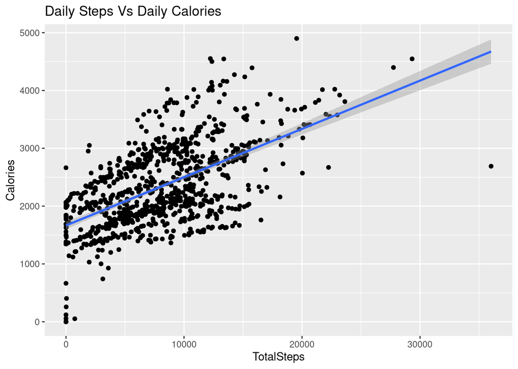

```r
steps_v_calories_plot <- ggplot(fitness_df, aes(x=TotalSteps, y=Calories)) + geom_point() + labs(title="Daily Steps Vs Daily Calories")
steps_v_calories_plot + geom_smooth(method = lm)
```

Lets check the correlation using the Pearson Correlation test.

```r
res <- cor.test(fitness_df$TotalSteps, fitness_df$Calories, method = "pearson")
res$estimate
```

```
##       cor
## 0.5915681
```

Now lets check the other activity types. Then We’ll plot the ones with the strongest correlation values.

```r
# very active minutes
very_active_min_correlation <- cor.test(fitness_df$VeryActiveMinutes, fitness_df$Calories, method = "pearson")
print(paste0("very active minutes:  ", very_active_min_correlation$estimate))
```

```
## [1] "very active minutes:  0.615838268270338"
```

```r
#fairly active minutes
fairly_active_min_correlation <- cor.test(fitness_df$FairlyActiveMinutes, fitness_df$Calories, method = "pearson")
print(paste0("fairly active minutes: ", fairly_active_min_correlation$estimate))
```

```
## [1] "fairly active minutes: 0.297623468265122"
```

```r
#lightly active minutes
lightly_active_min_correlation <- cor.test(fitness_df$LightlyActiveMinutes, fitness_df$Calories, method = "pearson")
print(paste0("lightly active minutes: ", lightly_active_min_correlation$estimate))
```

```
## [1] "lightly active minutes: 0.286717534017549"
```

```r
#total distance
total_distance_correlation<- cor.test(fitness_df$TotalDistance, fitness_df$Calories, method = "pearson")
print(paste0("total distance: ", total_distance_correlation$estimate))
```

```
## [1] "total distance: 0.644961872790222"
```

```r
#very active distance
very_active_distance_correlation<- cor.test(fitness_df$VeryActiveDistance, fitness_df$Calories, method = "pearson")
print(paste0("very active distance: ", very_active_distance_correlation$estimate))
```

```
## [1] "very active distance: 0.491958565066386"
```

```r
#moderately active distance
moderately_active_distance_correlation<- cor.test(fitness_df$ModeratelyActiveDistance, fitness_df$Calories, method = "pearson")
print(paste0("moderately active distance: ", moderately_active_distance_correlation$estimate))
```

```
## [1] "moderately active distance: 0.216789870324992"
```

```r
#lightly active distance
lightly_active_distance_correlation<- cor.test(fitness_df$LightActiveDistance, fitness_df$Calories, method = "pearson")
print(paste0("lightly active distance: ", lightly_active_distance_correlation$estimate))
```

```
## [1] "lightly active distance: 0.466916760945079"
```

So From this analysis we can see that the strongest correlations are from the values total distance, very active minutes, and total steps.

Since total distance and total steps accounts for all distances and steps of each effort level, we can see that the type of activity that burns the most calories is very active activity.

Lets take a look at the plot.

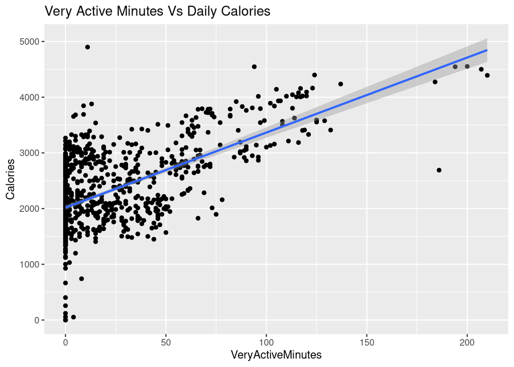

```r
very_active_min_v_calories_plot <- ggplot(fitness_df, aes(x=VeryActiveMinutes, y=Calories)) + geom_point() + labs(title="Very Active Minutes Vs Daily Calories")
very_active_min_v_calories_plot + geom_smooth(method = lm)
```

#### Reccomendation results from Analysis 1

We can see that Very Active Activity correlates with more calories burned. BellaBeats should let this data be known to its customers and encourage them to participate in very active activities if they are looking to burn more calories.